# Ford GoBike System

## by Omar Magdi

## Investigation Overview

> Insights on San Francisco Bay area, and how are the number of trips and it's duration are affected by various of reasons.

## Dataset Overview

> This data set includes information about individual rides made in a bike-sharing system covering the greater San Francisco Bay area.

## Frequency of trips against different variables

> These plots shows the distribution of frequency of trips against different variables. According to this graph it is concluded that male bikers out-number female bikers by 3 times. Most of the trips taken are by subscribers. Only few are by customers.

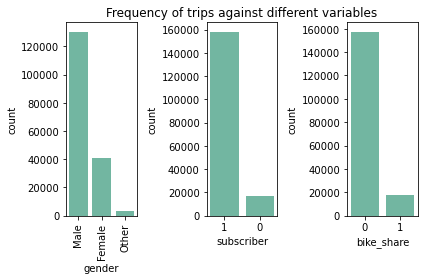

## Frequency of trips against Age

> The below plot shows peak trips at age of teenagers to mid 30's and drops gradually with increasing age.

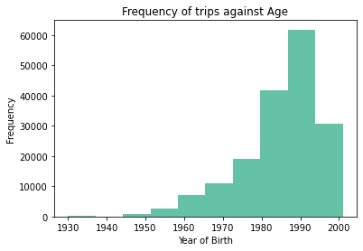

## Frequency of trips against weekdays

> Bikers are least active on weekends, the graph shows more activity on workdays, with Thursday holding the highest frequency of trips. I believe it is used as a mean of transportation across San Francisco.

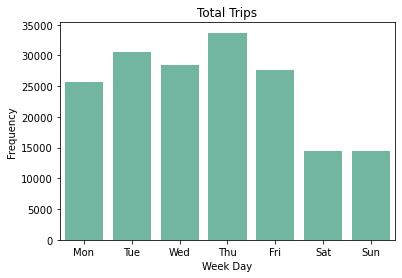

## Average duration of trips

> As we have seen in a previous slide, the number of trips by subscribers outnumbers the trips by customers by 8 times. In addition, the duration it takes to finish a trip by a subscriber is less than a customer by half.

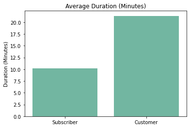

## Scatterplot showing the distribution of Duration of trips against Age for each gender.

> This is a Multivariate to clarify the effect of age and gender on the duration of trips.

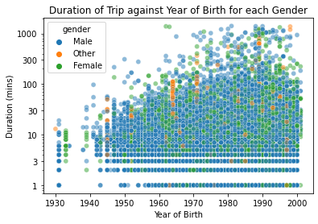